# Worldwide Spread of the Lesser Sneaking Ant, Cardiocondyla minutior (Hymenoptera: Formicidae)

1 June 2014 Worldwide Spread of the Lesser Sneaking Ant, *Cardiocondyla minutior* (Hymenoptera: Formicidae)

[James K. Wetterer](https://bioone.org/search?author=James_K._Wetterer)

[Author Affiliations +](https://bioone.org/)

[Florida Entomologist, 97(2)](https://bioone.org/journals/florida-entomologist/volume-97/issue-2):567-574 (2014). https://doi.org/10.1653/024.097.0231

Abstract

*Cardiocondyla* (Hymenoptera: Formicidae) ants are small and inconspicuous species. All *Cardiocondyla* are native to the Old World, but 5 species have been broadly dispersed through human commerce, achieving widespread distributions in both the Old World and the New World. Here I examine the worldwide spread of *Cardiocondyla minutior*. I compiled published and unpublished *C. minutior* specimen records from > 300 sites. I documented the earliest known *C. minutior* records for 56 geographic areas (countries, island groups, major Caribbean islands, and US states), including several for which I found no previously published records: Austral Islands, Barbados, Cuba, Dominican Republic, Grenada, Honduras, Îles Éparses, Jamaica, Madagascar, and Mayotte. *Cardiocondyla minutior* appears to be originally from the Indo-Malayan region, where all its closest relatives are found. Surprisingly, there are few records of *C. minutior* from this region. Instead, most Old World records of *C. minutior* come from Pacific and Indian Ocean islands where there are few or no native ants, e.g., the Chagos Archipelago, Hawaii, Îles Éparses, Easter Island, the Marquesas Islands, the Seychelles, and the Society Islands. *Cardiocondyla minutior* is becoming widespread in tropical and subtropical parts of the New World. The success of *Cardiocondyla* species in exotic locales may be due, in part, to their ability to co-exist with dominant invasive ants, such as the Argentine ant, *Linepithema humile*.

*Cardiocondyla* (Hymenoptera: Formicidae) ants are small and inconspicuous species, which Deyrup et al. (2000) dubbed “sneaking ants.” All *Cardiocondyla* are native to the Old World, but 5 species have achieved widespread distributions in the New World as well, spread by human com merce: *Cardiocondyla emeryi* Forel, *Cardiocondyla mauritanica* Forel, *Cardiocondyla minutior* Forel, *Cardiocondyla obscurior* Wheeler, and *Cardiocondyla wroughtonii* Forel. In earlier reviews, Wetterer (2012a, b) examined the spread *C. emeryi* and *C. mauritanica*. Here I examine the worldwide geographic spread of *C. minutior* (Fig. 1).

## Fig. 1.

*Cardiocondyla minutior*. Worker from Hilo, Hawaii, (1) head, (2) lateral view, (3) dorsal view (photos by A. Nobile, Antweb.org).

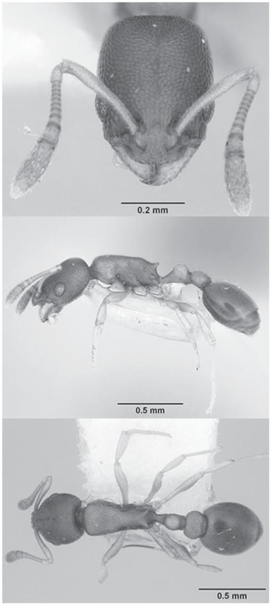

### Taxonomy, Identification, and Biology

Forel (1899) described *Cardiocondyla nuda minutior* (= *C. minutior*) from Hawaii. Wilson & Taylor (1967), however, designated *C. minutior* to be a junior synonym of *C. nuda*. Although Creighton (1950) tentatively treated *C. minutior* as a distinct subspecies of *C. nuda,* Creighton & Snelling (1974) wrote: “It now seems clear that the senior author was mistaken in treating Forel's variety *minutior* as a subspecies in 1950. At that time there were few long nest series of *nuda* available for study; hence it was not certain how the single nest series which had yielded workers of the typical *nuda* and others of the variety *minutior* ought to be handled. Subsequent studies have shown that the above situation is normally encountered in any long nest series of *nuda*. It follows that *minutior* must be treated as a synonym of *nuda*, as shown by Wilson and Taylor (1967).” Even after synonymy in 1967, some authors continued to use the name *C. nuda minutior* (e.g., Whitcomb et al. 1972). Heinze (1997, 1999), however, revived *C. minutior* as a full species. Seifert (2003) confirmed *C. minutior* as a valid species and determined *Cardiocondyla tsukuyomi* Terayama (described from Okinawa) to be a junior synonym of *C. minutior*. Seifert (2003) found genuine *C. nuda* records restricted to Australia, New Guinea, and Oceania. With the revival of *C. minutior* as a valid name, Fisher & Cover (2007) removed *C. nuda* from the list of ants known from North America.

One character which *C. minutior* shares with *C. nuda* is a flat dorsal mesosoma in profile with no distinct metanotal groove. This contrasts with the tramp species *C. emeryi, C. obscurior*, and *C. wroughtonii,* which have a distinct metanotal groove. It is relatively simple to distinguish *C. nuda* from *C. minutior*. In *C. nuda*, the postpetiolar sternite is convex and the height of petiole about equal to height of postpetiole. In *C. minutior*, the postpetiolar sternite is nearly flat and the maximum height of petiole greater than maximum height of postpetiole. Workers of *C. minutior* are generally smaller (total length = 1.5-1.7 mm) than those of *C. nuda* (total length = 1.6-2.0 mm), no doubt the basis of its Latin name “*minutior*,” meaning smaller or lesser.

Seifert (2003) noted “intraspecific variability in *C. minutior* is rather low within the huge range of its distribution, extending over the Neotropic, Polynesian, Australasian, Indo-Australasian, and Oriental regions. Samples from central Sri Lanka have significantly smaller eyes, those from Okinawa, N. India, and Nepal shorter heads but all these deviating populations are in the vast majority of other characters consistent with the overall average.”

Seifert (2003) placed *C. minutior* in the ‘*C. minutior* species group' along with six other species: *Cardiocondyla breviscapus* Seifert from In- dia, *Cardiocondyla carbonaria* Forel from India, *Cardiocondyla opaca* Seifert from India, *Cardiocondyla britteni* Crawley found on butter beans in England (probably imported from India), *Cardiocondyla goa* Seifert from India, and *Cardiocondyla tjibodana* Karavajev known from Indonesia, Malaysia, the Mariana Islands, and Belize. Oettler et al. (2010) found that *C. minutior* and *C*. *tjibodana* are genetically almost identical, and both are quite distinct from *C. nuda*.

*Cardiocondyla minutior* is one of several *Cardiocondyla* species known to have dimorphic males (Heinze et al. 2004; Oettler et al. 2010). Winged males disperse, typically after mating within their natal colony. Wingless males typically do not disperse from their natal colony. Instead, they fight other wingless males, typically resulting in the death of all but one resident male.

## Methods

Using published and unpublished records, I documented the worldwide range of *C. minutior*. I obtained unpublished site records from museum specimens in the collections of Archbold Biological Station (ABS, identified by M. Deyrup), the Museum of Comparative Zoology (MCZ, identified by S. Cover and M. Deyrup) and the Smithsonian Institution (SI, identified by M. Smith). W. P. Mackay sent me all *Cardiocondyla* specimens in his personal collection; M. Deyrup re-identified these specimens. In addition, I used on-line databases with collection information on specimens by Antweb.org, the Essig Museum of Entomology (essigdb.berkeley.edu), and the Global Biodiversity Information Facility ( www.gbif.org). I received unpublished *C. minutior* records from P. Ward (California, Colombia, Cuba, and Fiji). Finally, I collected *C. minutior* specimens on Pacific and West Indian islands.

I obtained geographic coordinates for collection sites from published references, specimen labels, maps, or geography web sites (e.g., earth.google. com, www.tageo.com, and www.fallingrain.com). If a site record listed a geographic region rather than a “point locale,” and I had no other record for this region, I used the coordinates of the largest town within the region or, in the case of small islands and natural areas, the center of the region. I did not map records of *C. minutior* on boats, found in newly imported goods, or intercepted in transit by quarantine inspectors. Published records usually included collection dates. In a number of cases, publications did not include the collection dates for specimens, but I was able to determine the date based on information from museum specimens, on the collector's travel dates, or limit the date by the collector's date of death. Stefan Cover confirmed identification for all specimens in the MCZ.

## Results

I compiled published and unpublished *C. minutior* specimen records from >300 sites (Fig. 2). I documented the earliest known *C. minutior* records for 56 geographic areas (countries, island groups, major Caribbean islands, and US states), including several for which I found no previously published records: Austral Islands, Barbados, Cuba, the Dominican Republic, Grenada, Honduras, Îles Éparses, Jamaica, Madagascar, and Mayotte (Tables 1 and 2).

Published records of *C. minutior* appear to be quite reliable, particularly in areas outside its purported native range, because authors reporting this relatively obscure taxon no doubt first determined the specimens were not the much more widely reported *C. nuda*. I found no cases where a specimen identified as *C. minutior* was later re-identified as a different species. Seifert (pers. comm.), however, wrote of his own identification: “You should know that all these determinations were achieved by an enormous measuring and analytical expense. Nobody (including me) can separate *minutior* and *tjibodana* by simple eye inspection. Both species possibly hybridize at localities where they were brought into contact. This is not verified but only suggested as the determinations are not very stable in some localities.” Seifert (pers. comm.) further warned that although *C. tjibodana* is only widespread in Indonesia and Malaysia, “findings of *tjibodana* from Belize, the Mariana Islands and Solomon Islands indicate that it has also some tramp species potential.” It is therefore possible that some of my mapped records of *C. minutior* are actually misidentified *C. tjibodana*. Alternatively, given their genetic closeness and possible inter-breeding, perhaps *C. minutior* and *C. tjibodana* are not actually distinct species.

### Re-Identification

Between 1967 and 1997, *C. minutior* was considered a junior synonym of *C. nuda*. Since the revival of *C. minutior*, some authors have re-identified published records of ‘*C. nuda*' as actually *C. minutior*. For example, Herrera & Roque-Albedo (2007) reported *C. nuda* from many islands in the Galapagos and no *C. minutior*, but Herrera & Heraty (2011) reported no *C. nuda* from the same islands, replacing all these records with *C. minutior*.

Before synonymy in 1967, there were several published records of *C. nuda minutior* from the New World (e.g., Wheeler 1932, Smith 1933, 1944, 1967, Vivar 1957), but none of *C. nuda*. It appears that subsequent published records of *C. nuda* from the New World may actually all be *C. minutior*. I confirmed with M. Deyrup, J. King, Z. Prusak, and J. A. Rodríguez (pers. comm.) that they now consider all specimens they reported as ‘*C. nuda*' from Florida, the Bahamas, and Mexico (e.g., Deyrup et al. 1988, 1998, 2000; Deyrup & Trager 1986; Deyrup 1994; Ferster & Prusak 1994; King 2007; Rodríguez 2008) as actually *C. minutior*. Torres & Snelling (1997) listed many records of *C. nuda* from Puerto Rico, but Snelling & Torres, in an unpublished book manuscript, changed all records of *C. nuda* to *C. minutior*. Oddly, although Fernández & Palacio (1995) listed *C. nuda* in Colombia, Fernández & Sendoya (2004) listed neither *C. nuda* nor *C. minutior* from anywhere in the Neotropics.

## Fig. 2.

Worldwide distribution records of *Cardiocondyla minutior*. Circle = *C. minutior* record. + = unconfirmed New World ‘*C. nuda*' record.

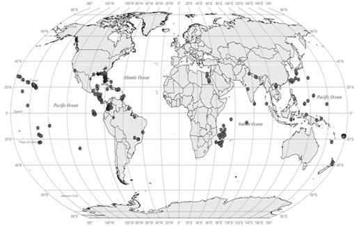

Mark Deyrup (pers. comm.) examined New World *Cardiocondyla* specimens in W. P. Mackay's collection and found specimens from 11 sites to be *C. minutior*: from Columbia (7 sites), Florida (1), Georgia (1), and Nicaragua (2), including 8 that Mackay (1995) previously listed as *C. nuda*. Deyrup re-identified 1 specimen that Mackay (1995) listed as *C. nuda* (from New Iberia, Louisiana) as *Cardiocondyla venustula* Wheeler. Finally, Deyrup was uncertain of the identity of 1 queen that Mackay (1995) listed as *C. nuda* (from Dauphin Island, Alabama).

I have mapped 11 unconfirmed records of ‘*C. nuda*' from the New World as *C. minutior* records (“+” in Fig. 2), i.e., Alabama (one record: Mackay 1995), Columbia (5 records: Mackay 1995, Armbrecht et al. 2001, and gbif), Georgia (one record: Smith 1979), Louisiana (2 records: Dash 2004), South Carolina (one record: Davis 2009), and Texas (Creighton & Snelling 1974). Only 2 New World areas with published records ‘*C. nuda*' lack any confirmed *C. minutior* records: Alabama and South Carolina (Table 2).

Wholesale replacement of the name *C. minutior* for ‘*C. nuda*' in the New World cannot be repeated in the Asia and Oceania, where true *C. nuda* occurs. In addition, several other species in the Old World have been misidentified as *C. nuda*. For example, many published records of ‘*C. nuda*' from the Palearctic are actually *C. mauritanica* (Seifert 2003, Wetterer 2012b). Starr et al. (2007) wrote: “In Hawaii, specimens of this species were previously called *C. nuda* in error, so all previous records of *C. nuda* are now considered *C. minutior* (Krushelnycky pers. comm.).” Seifert (2003), however, noted that some specimens from Pacific region identified previously as ‘*C. nuda*' are actually *Cardiocondyla kagutsuchi* Terayama, a species from East Asia and Oceania that has been recently reported from Hawaii (e.g., Seifert 2003; Buczkowski & Krushelnycky 2012). Jürgen Heinze (pers. comm.) wrote: “in my opinion, *C. kagutsuchi* is the most widespread *Cardiocondyla* inland at least in Hawai'i and Kauai. What has been referred to as *C. nuda* or *C. venustula* is mostly *C. kagutsuchi*. They occur even in na- tional parks far from the coast at elevations of 1000m and more and in some areas are the only ants around. *C. venustula* appears much rarer.” I therefore only mapped Hawaiian records specifically identified as *C. minutior*.

## Table 1.

Earliest known records for *Cardiocondyla minutior* from 29 old world areas. Unpublished records include collector, museum or web source, and site. mcz = Museum of Comparative Zoology. ucb = Essig Museum of the University of California, Berkeley. + = No known published record.

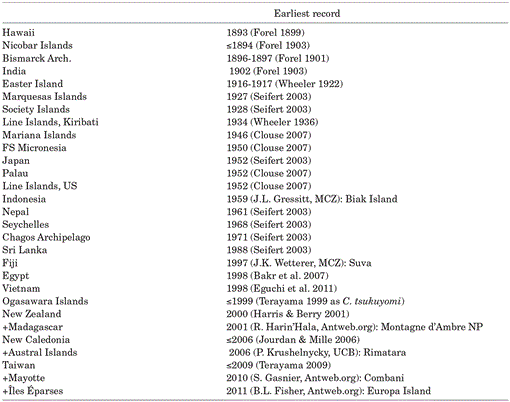

Seifert (2003) listed site records of *C. minutior* from the Marquesas Islands (Kopaafaa, Hiva Oa; 1927; collected by A. M. Adamson & E. P. Mumford) and the Society Islands (Hitiaa, Tahiti; 1928; collected by A. M. Adamson) from the Museum of Comparative Zoology that match reports by Wilson & Taylor (1967) of *C. emeryi*, suggesting that these are *C. minutior* specimens previously misidentified as *C. emeryi*. Eguchi et al. (2011) reported that the specimens that Eguchi et al. (2005) listed as *C. emeryi* were actually *C. minutior*.

Forel (1903) reported *C. nuda minutior* (= *C. minutior*) from Kondul Island in the Nicobar Islands, but Mohanraj et al. (2010) incorrectly reported Forel's (1903) record as *C. nuda*.

## Discussion

Most Old World records of *C. minutior* have come from oceanic islands with few or no native ants, e.g., Hawaii, Easter Island, the Marquesas Islands, the Society Islands, the Seychelles, and the Chagos Archipelago. *Cardiocondyla minutior*, however, appears to be originally from the Indo- Malayan region, where all its closest relatives are found (Seifert 2003). *Cardiocondyla minutior* specimens from Sri Lanka, Okinawa, India, and Nepal are morphologically more variable than those collected in the rest of the world (Seifert 2003), providing further evidence that *C. minutior* is native to this region. There are surprisingly few records of *C. minutior* from the Indo-Malayan region (Fig. 2), though this may simply be a testament to how inconspicuous and difficult to identify these ants are. Many, if not most, published records of *C. nuda* from the Indo-Malayan region (e.g., Thailand; Jaitrong & Nabhitabhata 2005) may be based on misidentifications of *C. minutior*. In this case, the dates of the earliest known records of *C. minutior* in the Old World appear to provide little guidance concerning where this species originated.

## Table 2.

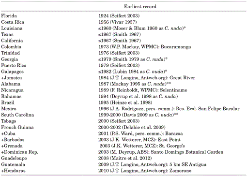

The success of *Cardiocondyla* species in exotic locales may be due, in part, to their ability of coexist with dominant invasive ants (Heinze et al. 2006). Ito (1953) reported *C. minutior* occurring in an area occupied by the Argentine ant, *Linepithema humile* (Mayr, 1868), in Opaeula, Hawaii and speculated that *C. minutior* “was perhaps tolerated or overlooked by the Argentine ant because of its minute size.” Wilson & Taylor (1967) noted that *L. humile* “excludes other larger ant species, including the formidable *Pheidole megacephala*. One species found to be compatible with it on Hawaii is the diminutive *Cardiocondyla nuda*” (possibly referring to *C. minutior*, which they had newly synonymized with *C. nuda*). Ward (2005) reported that both *C. mauritanica* and *C. minutior* “are able to survive in sites invaded by the Argentine ant,” *L. humile*.

Five species of *Cardiocondyla* have become cosmopolitan tramps and have achieved widespread distributions in both the Old World and the New World: *C. emeryi*, *C. mauritanica*, *C. minutior*, *C. obscurior*, and *C. wroughtonii* (Seifert 2003). Several additional *Cardiocondyla* species have begun to spread outside their native range, including *C. kagutsuchi*, *C. tjibodana*, and *C. venustula*. None of these species, however, are known to have significant ecological impacts, and it seems unlikely that any of these inconspicuous sneaking ants will ever become significant pests as they continue to spread, largely unnoticed, around the world.

## Acknowledgments

I thank M. Wetterer, B. Seifert, and J. Heinze for comments on this manuscript; S. Cover (MCZ) and M. Deyrup (ABS) for help, encouragement, and ant identification; P. Ward, J. Chaul, and D. McDonald for providing unpublished records; M. Deyrup, J. King, Z. Prusak, and J. A. Rodríguez for additional information; B. Guénard for sending overlooked references; W. O'Brien for GIS help; D. P. Wojcik and S. D. Porter for compiling their valuable FORMIS bibliography; R. Pasos and W. Howerton of the FA U library for processing so many interlibrary loans; Florida Atlantic University and the National Science Foundation (DES-0515648) for financial support.

## References Cited

1.

I. Armbrecht , I. Tischer , and P. Chacon 2001. Nested subsets and partition patterns in ant assemblages (Hymenoptera, Formicidae) of Colombian dry forest fragments. Pan-Pac. Entomol. 77: 196–209. Google Scholar

2.

R. F. A. Bakr , H. H. Fadl , R. M. Badawy , and M. R. Sharaf 2007. Myrmecophile insects associated with some ant species (Hymenoptera: Formicidae) in Egypt. Second Intl. Conf. Econ. Entomol. 1: 205–233. Google Scholar

3.

G. Buczkowski , and P. Krushelnycky 2012. The odorous house ant, *Tapinoma sessile* (Hymenoptera: Formicidae), as a new temperate-origin invader. Myrmecol. News 16: 61–66. Google Scholar

4.

R. M. Clouse 2007. The ants of Micronesia (Hymenoptera: Formicidae). Micronesica 39: 171–295. Google Scholar

5.

W. S. Creighton and R. R. Snelling 1974. Notes on the behavior of three species of *Cardiocondyla* in the United States (Hymenoptera: Formicidae). J. N. Y. Entomol. Soc. 82: 82–92. Google Scholar

6.

W. S. Creighton 1950. The ants of North America. Bull. Mus. Compar. Zool. 104: 1–585. [Google Scholar](http://scholar.google.com/scholar_lookup?title=The+ants+of+North+America.&volume=104&publication_year=1950&pages=1-585)

7.

S. T. Dash 2004. Species diversity and biogeography of ants (Hymenoptera: Formicidae) in Louisiana, with notes on their ecology. M.S. thesis, Louisiana State Univ. 290 pp. [Google Scholar](http://scholar.google.com/scholar_lookup?&publication_year=2004&pages=290)

8.

T. S. Davis 2009. The Ants of South Carolina. PhD dissertation, Clemson Univ. 272 pp. [Google Scholar](http://scholar.google.com/scholar_lookup?&publication_year=2009&pages=272)

9.

J. H. C. Delabie , R. Céréghino , S. Groc , A. Dejean , M. Gibernau , B. Corbara & A. Dejean 2009. Ants as biological indicators of Wayana Amerindian land use in French Guiana. C. R. Biol. 332: 673–684. [Google Scholar](http://scholar.google.com/scholar_lookup?title=Ants+as+biological+indicators+of+Wayana+Amerindian+land+use+in+French+Guiana.&volume=332&publication_year=2009&pages=673-684)

10.

M. Deyrup , and J. Trager 1986. Ants of the Archbold Biological Station, Highlands County, Florida (Hymenoptera: Formicidae). Florida Entomol. 69: 206–228. Google Scholar

11.

M. Deyrup 1994. Biogeographical survey of the ants of the island of San Salvador, Bahamas. pp. 21–28. in L.B. Kass (ed.) Proc. Fifth Symp. Nat. Hist. Bahamas. Bahamian Field Sta., San Salvador, Bahamas. [Google Scholar](http://scholar.google.com/scholar_lookup?&publication_year=1994&pages=21-28)

12.

M. Deyrup , L. Davis , and S. Buckner 1998. Composition of the ant fauna of three Bahamian islands. pp. 23-31 in Proc. 7th Symp. Natur. Hist. Bahamas, Bahamian Field Station, San Salvador, Bahamas. [Google Scholar](http://scholar.google.com/scholar_lookup?title=Composition+of+the+ant+fauna+of+three+Bahamian+islands.&publication_year=1998&pages=23-31)

13.

M. Deyrup , L. Davis , and S. Cover 2000. Exotic ants in Florida. Trans. American Entomol. Soc. 126: 293–326. [Google Scholar](http://scholar.google.com/scholar_lookup?title=Exotic+ants+in+Florida.&volume=126&publication_year=2000&pages=293-326)

14.

15.

K. Eguchi , T. V. Bui , Sk. Yamane , H. Okido , and K. Ogata 2005. Ant fauna of Ba Vi and Tam Dao, N. Vietnam (Insecta: Hymenoptera: Formicidae). Bull. Inst. Trop. Agric. Kyushu Univ. 27: 77–98. Google Scholar

16.

17.

F. Fernández , and E. E. Palacio 1995. Hormigas de Colombia IV: nuevos registros de generos y especies. Caldasia 17: 82–85. [Google Scholar](http://scholar.google.com/scholar_lookup?title=Hormigas+de+Colombia+IV:+nuevos+registros+de+generos+y+especies.&volume=17&publication_year=1995&pages=82-85)

18.

F. Fernández , and S. Sendoya 2004. Synonymic list of Neotropical ants (Hymenoptera: Formicidae). Biota Colombiana 5: 3–105. Google Scholar

19.

B. Ferster , and Z. Prusak 1994. A preliminary checklist of the ants (Hymenoptera: Formicidae) of Everglades National Park. Florida Entomol. 77: 508–512. Google Scholar

20.

B. L. Fisher , and S. P. Cover 2007. Ants of North America: a guide to the genera. Univ. Calif. Press, Berkeley and Los Angeles, 194 pp. [Google Scholar](http://scholar.google.com/scholar_lookup?&publication_year=2007&pages=194)

21.

A. Forel 1899. Heterogyna (Formicidae). Fauna Hawaiiensis 1: 116–122. Google Scholar

22.

A. Forel 1901. Formiciden aus dem Bismarck-Archipel, auf Grundlage des von Prof. Dr. F. Dahl gesammelten Material. Mitt. Zool. Mus. Berl. 2: 4–37. [Google Scholar](http://scholar.google.com/scholar_lookup?title=Formiciden+aus+dem+Bismarck-Archipel,+auf+Grundlage+des+von+Prof.+Dr.+F.+Dahl+gesammelten+Material.&volume=2&publication_year=1901&pages=4-37)

23.

A. Forel 1903. Les fourmis des îles Andamans et Nicobares. Rapports de cette faune avec ses voisines. Rev. Suisse Zool. 11: 399–411. [Google Scholar](http://scholar.google.com/scholar_lookup?title=Les+fourmis+des+%C3%AEles+Andamans+et+Nicobares.+Rapports+de+cette+faune+avec+ses+voisines.&volume=11&publication_year=1903&pages=399-411)

24.

R. J. Harris , and J. A. Berry 2001. Confirmation of the establishment of three adventive ants (Hymenoptera: Formicidae) in New Zealand: *Cardiocondyla minutior* Forel, *Ponera leae* Forel, *Mayriella abstinens* Forel. New Zealand Entomol. 24: 53–56. Google Scholar

25.

J. Heinze 1997. Male reproductive strategies in ants. pp. 179–187 *In* V. E. Kipyatkov [ed.], Proc. Intl. Coll. Social Insects. Socium, St. Petersburg. [Google Scholar](http://scholar.google.com/scholar_lookup?title=Male+reproductive+strategies+in+ants.&publication_year=1997&pages=179-187)

26.

J. Heinze 1999. Male polymorphism in the ant species *Cardiocondyla minutior* (Hymenoptera: Formicidae). Entomol. Gen. 23: 251–258. Google Scholar

27.

J. Heinze , A. Böttcher , and S. Cremer 2004. Production of winged and wingless males in the ant, *Cardiocondyla minutior*. Insect. Soc. 51: 275–278. [Google Scholar](http://scholar.google.com/scholar_lookup?title=Production+of+winged+and+wingless+males+in+the+ant,+Cardiocondyla+minutior.&volume=51&publication_year=2004&pages=275-278)

28.

J. Heinze , S. Cremer , N. Eckl , and A. Schrempf 2006. Stealthy invaders: the biology of *Cardiocondyla* tramp ants. Insect. Soc. 53: 1–7. [Google Scholar](http://scholar.google.com/scholar_lookup?title=Stealthy+invaders:+the+biology+of+Cardiocondyla+tramp+ants.&volume=53&publication_year=2006&pages=1-7)

29.

J. Heinze , B. Hölldobler , and K. Yamauchi 1998. Male competition in *Cardiocondyla* ants. Behav. Ecol. Sociobiol. 42: 239–246. [Google Scholar](http://scholar.google.com/scholar_lookup?title=Male+competition+in+Cardiocondyla+ants.&volume=42&publication_year=1998&pages=239-246)

30.

H. W. Herrera , and J. M. Heraty 2011. CDF Checklist of Galapagos Ants, bees, wasps and related groups. In: F. Bungartz , H. Herrera , P. Jaramillo , N. Tirado , G. Jímenez-Uzcategui , D. Ruiz , Guézou, and A. Ziemmeck , F. [eds.], Charles Darwin Foundation Galapagos Species Checklist. Charles Darwin Found., Pto. Ayora, Galapagos. [Google Scholar](http://scholar.google.com/scholar_lookup?title=CDF+Checklist+of+Galapagos+Ants,+bees,+wasps+and+related+groups.&publication_year=2011)

31.

H. W. Herrera , and L. Roque-Albela 2007. Lista anotoda de las hormigas de las Islas Galápagos, Ecuador. Minist. Ambiente, Ecuador. 13 pp. [Google Scholar](http://scholar.google.com/scholar_lookup?&publication_year=2007&pages=13)

32.

K. Ito 1953. Notes and exhibitions: Argentine ant. Proc. Hawaiian Entomol. Soc. 15: 13–15. [Google Scholar](http://scholar.google.com/scholar_lookup?title=Notes+and+exhibitions:+Argentine+ant.&volume=15&publication_year=1953&pages=13-15)

33.

W. Jaitrong , and J. Nabhitabhata 2005. A list of known ant species of Thailand (Formicidae: Hymenoptera). Thailand Nat. Hist. Mus. J. 1: 9–54. Google Scholar

34.

H. Jourdan , and C. Mille 2006. Les invertébrés introduits dans l'archipel néo-calédonien: espèces envahissantes et potentiellement envahissantes. Première évaluation et recommandations pour leur gestion, pp. 163–214 *In* M.-L. Beauvais , A. Coléno and H. Jourdan [eds.], Espèces envahissantes dans l'archipel néocalédonien. Fonds IRD, Montpellier, France. Google Scholar

35.

J. R. King 2007. Patterns of co-occurrence and body size overlap among ants in Florida's upland ecosystems. Ann. Zool. Fennici 44: 189–201. [Google Scholar](http://scholar.google.com/scholar_lookup?title=Patterns+of+co-occurrence+and+body+size+overlap+among+ants+in+Florida%27s+upland+ecosystems.&volume=44&publication_year=2007&pages=189-201)

36.

Y. D. Lubin 1984. Changes in the native fauna of the Galápagos Islands following invasion by the little red fire ant, *Wasmannia auropunctata*. Biol. J. Linn. Soc. 21: 229–242. Google Scholar

37.

W. P. Mackay 1995. New distributional records for the ant genus *Cardiocondyla* in the New World (Hymenoptera: Formicidae). Pan-Pac. Entomol. 71: 169–172. Google Scholar

38.

J. B Maitre , R. Goebel , and B. Vercambre 2012. Evidence of the role of predatory ants in natural pest control in banana-sugarcane rotation systems. Faunistic Entomol. 65: 49–68. [Google Scholar](http://scholar.google.com/scholar_lookup?title=Evidence+of+the+role+of+predatory+ants+in+natural+pest+control+in+banana-sugarcane+rotation+systems.&volume=65&publication_year=2012&pages=49-68)

39.

P. Mohanraj , M. Ali , and K. Veenakumari 2010. Formicidae of the Andaman and Nicobar Islands (Indian Ocean: Bay Of Bengal). J. Insect Sci. 10:172. doi: 10.1673/031.010.14132. Google Scholar

40.

J. C. Moser , and M. S. Blum 1960. The Formicidae of Louisiana. Insect Condit. Louisiana 3: 48–50. [Google Scholar](http://scholar.google.com/scholar_lookup?title=The+Formicidae+of+Louisiana.+Insect+Condit.&volume=3&publication_year=1960&pages=48-50)

41.

J. Oettler , M. Suefuji , and J. Heinze 2010. The evolution of alternative reproductive tactics in male *Cardiocondyla* ants. Evolution 64: 3310–3317. [Google Scholar](http://scholar.google.com/scholar_lookup?title=The+evolution+of+alternative+reproductive+tactics+in+male+Cardiocondyla+ants.&volume=64&publication_year=2010&pages=3310-3317)

42.

J. A. Rodríguez 2008. Hormigas (Hymenoptera: Formicidae) del estado de Yucatán: nuevos registros. Entomol. Mex. 7: 1006–1008. Google Scholar

43.

B. Seifert 2003. The ant genus *Cardiocondyla* (Insecta: Hymenoptera: Formicidae) a taxonomic revision of the *C. elegans*, *C. bulgarica*, *C. batesii*, *C. nuda*, *C. shuckardi*, *C. stambuloffii*, *C. wroughtonii*, *C. emeryi* and *C. minutior* species groups. Ann. Naturhist. Mus. Wien 104(B): 203–338. Google Scholar

44.

M. R. Smith 1933. Additional species of Florida ants, with remarks. Florida Entomol. 17: 21–26. [Google Scholar](http://scholar.google.com/scholar_lookup?title=Additional+species+of+Florida+ants,+with+remarks.&volume=17&publication_year=1933&pages=21-26)

45.

M. R. Smith 1944. Ants of the genus *Cardiocondyla* Emery in the United States. Proc. Entomol. Soc. Washington 46: 30–41. [Google Scholar](http://scholar.google.com/scholar_lookup?title=Ants+of+the+genus+Cardiocondyla+Emery+in+the+United+States.&volume=46&publication_year=1944&pages=30-41)

46.

M. R. Smith 1967. Family Formicidae, pp. 343–374 *In* K. V. Krombein and B. D. Burks [eds.], Hymenoptera of America north of Mexico. Synoptic catalog. Second suppl.. U. S. Dept. Agric., Agric. Monogr. 2 (suppl. 2). [Google Scholar](http://scholar.google.com/scholar_lookup?title=Family+Formicidae&publication_year=1967&pages=343-374)

47.

M. R. Smith 1979. Superfamily Formicoidea, pp. 1323–1467 *In* K. V. Krombein , P. D. Hurd Jr., D. R. Smith and B. D. Burks [eds.], Catalog of Hymenoptera in America North of Mexico. Volume 2. Apocrita (Aculeata). Smithsonian Inst. Press, Washington DC. [Google Scholar](http://scholar.google.com/scholar_lookup?title=Superfamily+Formicoidea&publication_year=1979&pages=1323-1467)

48.

F. Starr , K. Starr , and L. L. Loope 2007. Survey for little fire ant (*Wasmannia auropunctata*) on the island of Maui, Hawaii. Hawaiian Ecosystems at Risk project (HEAR). Puunene, Hawaii. 35 pp. [Google Scholar](http://scholar.google.com/scholar_lookup?&publication_year=2007&pages=35)

49.

M. Terayama 1999. Taxonomic studies of the Japanese Formicidae, Part 6. Genus *Cardiocondyla* Emery. Mem. Myrmecol. Soc. Japan 1: 99–107. [Google Scholar](http://scholar.google.com/scholar_lookup?title=Taxonomic+studies+of+the+Japanese+Formicidae,+Part+6.+Genus+Cardiocondyla+Emery.&volume=1&publication_year=1999&pages=99-107)

50.

M. Terayama 2009. A synopsis of the family Formicidae of Taiwan (Insecta: Hymenoptera). Res. Bull. Kanto Gakuen Univ. Liberal Arts 17: 81–266. Google Scholar

51.

J. A. Torres , and R. R. Snelling 1997. Biogeography of Puerto Rican ants: a non-equilibrium case? Biodiv. Conserv. 6: 1103–1121. [Google Scholar](http://scholar.google.com/scholar_lookup?title=Biogeography+of+Puerto+Rican+ants:+a+non-equilibrium+case?&volume=6&publication_year=1997&pages=1103-1121)

52.

V. L. Vivar 1957. Naturaleza, comportamiento y distribución de las hormigas en una plantación de abacá. MS Thesis, Inst. Interamer. Cien. Agríc., Turrialba, Costa Rica. [Google Scholar](http://scholar.google.com/scholar_lookup?&publication_year=1957)

53.

P. S. Ward 2005. A synoptic review of the ants of California (Hymenoptera: Formicidae). Zootaxa 936: 1–68. Google Scholar

54.

J. K. Wetterer 2012a. Worldwide spread of Emery's sneaking ant, *Cardiocondyla emeryi* (Hymenoptera: Formicidae). Myrmecol. News 17: 13–20. Google Scholar

55.

J. K. Wetterer 2012b. Worldwide spread of the Moorish sneaking ant, *Cardiocondyla mauritanica* (Hymenoptera: Formicidae). Sociobiology 59: 985–997. Google Scholar

56.

57.

W. M. Wheeler 1932. A list of the ants of Florida with descriptions of new forms. J. New York Entomol. Soc. 40: 1–17. [Google Scholar](http://scholar.google.com/scholar_lookup?title=A+list+of+the+ants+of+Florida+with+descriptions+of+new+forms.&volume=40&publication_year=1932&pages=1-17)

58.

W. M. Wheeler 1936. Ants from the Society, Austral, Tuamotu and Mangareva Islands. Occas. Pap. Bernice P. Bishop Mus. 12(18): 3–17. [Google Scholar](http://scholar.google.com/scholar_lookup?title=Ants+from+the+Society,+Austral,+Tuamotu+and+Mangareva+Islands.&volume=12&issue=18&publication_year=1936&pages=3-17)

59.

W. H. Whitcomb , H. A. Denmark , A. P. Bhatkar , and G. L. Greene 1972. Preliminary studies on the ants of Florida soybean fields. Florida Entomol. 55: 129–142 [Google Scholar](http://scholar.google.com/scholar_lookup?title=Preliminary+studies+on+the+ants+of+Florida+soybean+fields.&volume=55&publication_year=1972&pages=129-142)

60.

E. O. Wilson , and R. W. Taylor 1967. Ants of Polynesia. Pacific Insects Monogr. 14: 1–109. [Google Scholar](http://scholar.google.com/scholar_lookup?title=Ants+of+Polynesia.&volume=14&publication_year=1967&pages=1-109)

[James K. Wetterer](https://bioone.org/search?author=James_K._Wetterer) "Worldwide Spread of the Lesser Sneaking Ant, *Cardiocondyla minutior* (Hymenoptera: Formicidae)," Florida Entomologist 97(2), 567-574, (1 June 2014). https://doi.org/10.1653/024.097.0231

Published: 1 June 2014

JOURNAL ARTICLE  
8 PAGES

SHARE

GET CITATION

|

ARTICLE SOURCE

[figure not shown]

**Florida Entomologist**  
Vol. 97 • No. 2  
June 2014

KEYWORDS

[biogeografía](https://bioone.org/search?keyword=biogeograf%C3%ADa)

biogeography

[biological invasion](https://bioone.org/search?keyword=biological_invasion)

[especies exóticas](https://bioone.org/search?keyword=especies_ex%C3%B3ticas)

[especies invasoras](https://bioone.org/search?keyword=especies_invasoras)

[exotic species](https://bioone.org/search?keyword=exotic_species)

[fauna de islas](https://bioone.org/search?keyword=fauna_de_islas)